# week1_codrone_setup - revised

**CoDrone Setup**

By Prof. Seungchul Lee  
http://iai.postech.ac.kr/  
Industrial AI Lab at POSTECH

Table of Contents

- Please submit the following files after today's class.
  - ipynb files
  - Demonstration videos of your drone
- TA's E-mail : juwonna7@postech.ac.kr
  - The title of your mail should be "[MECH199-01][Drone & RC Car] (Group Name) WEEK1"

# 1. Course Overview

- To provide freshmen a chance to experience system design through mechatronics practice of drone and mobile robot project.
- Drone project (semi-project)
  - Understand drones' flight principles
  - Use Python to control drones
  - Perform simple missions using Python coding
- Mobile robot project (final-term project)
  - Understand the theory of sensors and communication methods
  - Combine software and hardware to create a single system

## 1.1. Drone Control Project

- Codrone Specification

[figure not shown]

- Basics for quadcopter movement
- Principles of driving method and concept of hovering

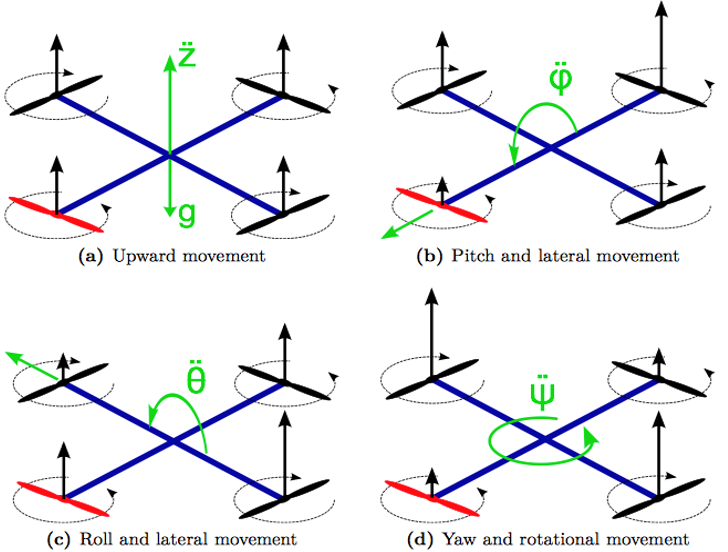

- Tentative mission
  - Assume a disaster situation
  - Control their drone to pass through obstacles, burst a balloon in a fire building, and return to land at a designated landing point

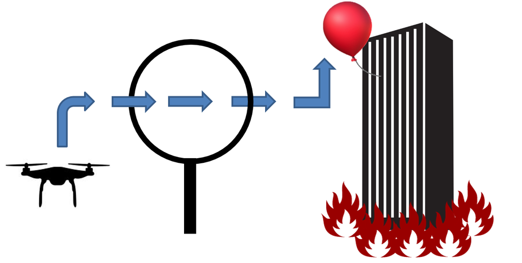

- Drone Control Project(Video)

[video not shown]

## 1.2. Mobile Robot Project

- Mobile Robot Specification
  - Car design is the responsibility of students

[figure not shown]

[figure not shown]

- Time Attack Mission

[figure not shown]

- Mobile Robot Project(Video)

[video not shown]

# 2. Python Setup

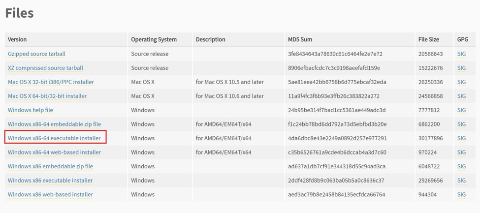

**[2]** Run the installer

- You must add Python 3.5 to PATH

[figure not shown]

**[3]** Make sure the installation is good

- Type "python" in the Windows Command Prompt

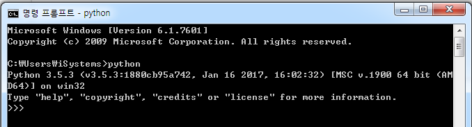

**[4]** Jupyter notebook & CoDrone installation

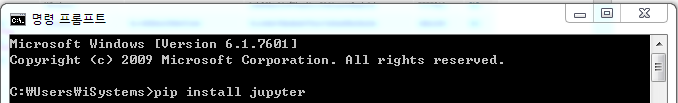

**[5]** Running Jupyter notebook

- Type 'Jupyter notebook' in folder's domain

[figure not shown]

**[6]** Create Jupyter notebook

- Click 'New'
- Select 'Python 3'

[figure not shown]

## 2.1. Python Basic Coding

**[1]** Variable

```python
x = 3
y = 3.14
greet = "Hello World"
```

**[2]** Print

```python
print("안녕하세요")
print(greet)
```

```
안녕하세요
Hello World
```

**[3]** Basic Operator

- Python Arithmetic Operators

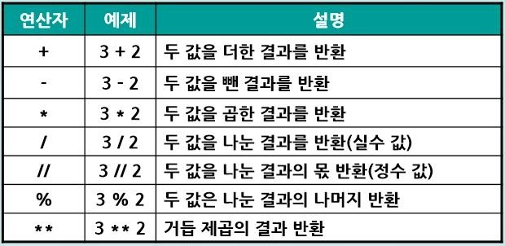

- Python Comparison Operators

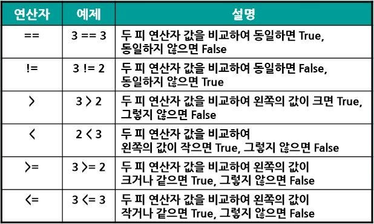

- Python Logical Operators

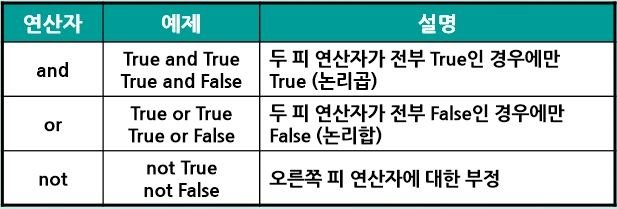

```python
print(x + y)
print(x < y)
print(x == y)
print(x < y or x > y)
```

```
6.140000000000001
True
False
True
```

**[4]** If statement

```python
if x < y :
    print("x가 y보다 작습니다.")

if x < y :
    print("x가 y보다 작습니다.")
elif x == y:
    print("x와 y가 같습니다.")
else:
    print("x가 y보다 큽니다.")
```

```
x가 y보다 작습니다.
x가 y보다 작습니다.
```

**[5]** For / While statement

```python
print('For Loop:')
for i in range(10):
    print(i, end=' ')

print('\nWhile Loop:')
i = 0
while i < 10:
    print(i, end=' ')
    i += 1
```

```
For Loop:
0 1 2 3 4 5 6 7 8 9
While Loop:
0 1 2 3 4 5 6 7 8 9
```

# 3. CoDrone Steup

## 3.1. Drone Bluetooth Module Connection

**[1]** CP210X_Universal_Windows_Driver 설치

- 아래 링크에 들어가서 자신의 OS Version과 맞는 파일을 다운
- https://www.silabs.com/products/development-tools/software/usb-to-uart-bridge-vcp-drivers

**[2]** CP210x_Universal_Windows_Driver.zip 압축해제

**[3]** CP210x_Universal_Windows_Driver 폴더에서 아래 설치파일들 중 자신의 OS 에 맞는 설치파일 실행

- CP210xVCPInstaller_x64 (64 Bit)
- CP210xVCPInstaller_x86 (32 Bit)

**[4]** Bluetooth Module 을 노트북에 연결 (USB 포트)

**[5]** 윈도우 마크 우클릭 후 장치 관리자 열어서 포트에 아래 항목이 연결되어있는지 확인

- Silicon Labs CP210x USB to UART Bridge

[figure not shown]

## 3.2. Drone Pairing

**[1]** Jupyter Notebook 실행

**[2]** Bluetooth Module 을 아래처럼 master mode 로 설정

```
- 1 : off, 2 : on
```

**[3]** CoDrone Library Import

```python
from CoDrone.codrone import *
```

**[3]** Pairing Code 실행 (Nearest Drone Pairing)

```
- Pairing 하기 전 반드시 조교에게 먼저 허락을 받으세요.
```

```python
drone = CoDrone()
drone.pair(drone.Nearest)

if drone.isConnected():
    print('Codrone이 성공적으로 페어링되었습니다.')

drone.close()
```

```
>> Port : [COM3]
>> Drone : [3218]
>> Battery : [0]
>> Low Battery!!
Codrone이 성공적으로 페어링되었습니다.
```

**[3]** 4자리 정수의 Address 을 기록하여 다음 페이링부터는 Address 로 페어링 할 수 있도록 함 (본 예제의 경우 3218)

```python
drone = CoDrone()
drone.pair('3218')

if drone.isConnected():
    print('Codrone이 성공적으로 페어링되었습니다.')
```

```
>> Port : [COM3]
>> Drone : [3218]
>> Battery : [0]
>> Low Battery!!
Codrone이 성공적으로 페어링되었습니다.
```

**[4]** 드론의 후미등이 BLINK 에서 Solid로 바뀌었는지 확인

**[5]** 아래 error가 뜰 경우에는 Bluetooth Module 을 뽑았다가 다시 연결하세요

- SerialException: could not open port 'COM#' : PermissionError(#, '액세스가 거부되었습니다.', None, #)

# 4. Turn on LED

## 4.1. CoDrone Library

**[1]** CoDrone Library Reference page 열기

- http://dev-support.robolink.com/

**[2]** Reference 를 참고하되 Tap key 를 이용하여 함수 사용에 어려움이 없도록 하세요

## 4.2. LED Control

**[1]** 예제 코드

```python
if drone.isConnected():
    drone.set_all_led(Color.Green, Mode.BLINK)
    sleep(5)
    drone.set_all_led(Color.Green, Mode.OFF)
```

**[2]** 예제 코드의 함수 외에 다른 함수를 사용하여 LED 조절해보세요.

```python
# fill your code
```

```python
%%javascript

$.getScript('https://kmahelona.github.io/ipython_notebook_goodies/ipython_notebook_toc.js')
```